# Search Console a manipulace s daty

Marek Prokop

[PROKOP software s.r.o.](https://www.prokopsw.cz/cs)

26. 2. 2024

## V této části se naučíte:

1. Načítat data ze Search Console
2. Základní operace s dataframy
3. Kreslení grafů

## Nainstalujte si nejnovější verzi *searchConsoleR*

Z konsole:

```r
devtools::install_github("MarkEdmondson1234/searchConsoleR")
```

## Uložte si svůj účet Google

Z konsole:

```r
usethis::edit_r_environ()
```

Otevře se textový soubor, do kterého přidejte řádek:

```
MY_GOOGLE_ACCOUNT = "my.name@gmail.com"
```

Soubor uložte a restartujte R session (*Session* ➔ *Restart R*).

Tento postup stačí udělat na každém počítači jen jednou.

## Potřebné balíčky

```r
library(tidyverse)
library(searchConsoleR)
```

## Autorizace a přístupné weby

```r
scr_auth(email = Sys.getenv("MY_GOOGLE_ACCOUNT"))
list_websites()
```

|  | siteUrl | permissionLevel |
| --- | --- | --- |
| 1 | https://www.eros.sk/ | siteRestrictedUser |
| 2 | sc-domain:fitness4u.cz | siteFullUser |
| 3 | http://archisview.blogspot.com/ | siteOwner |
| 4 | sc-domain:sportega.fr | siteFullUser |
| 5 | https://prokopsw.cz/ | siteOwner |
| 6 | https://www.eroticke-pomucky.cz/ | siteFullUser |
| 7 | http://www.prokopsw.cz/ | siteOwner |
| 8 | https://www.lampes-projecteurs.fr/ | siteFullUser |
| 9 | https://www.jointjs.com/ | siteRestrictedUser |
| 10 | http://www.firemnivino.cz/ | siteRestrictedUser |

[output cut: 132 more lines]

## Filtrování podle části URL

```r
list_websites() |>
  filter(str_detect(siteUrl, "marekp.cz"))
```

| siteUrl | permissionLevel |
| --- | --- |
| http://www.marekp.cz/ | siteOwner |

```r
my_site <- list_websites() |>
  filter(str_detect(siteUrl, "marekp.cz")) |>
  pull(siteUrl)

my_site
```

```
[1] "http://www.marekp.cz/"
```

## Načtení dat - minimalistická verze

```r
search_analytics(siteURL = my_site)
```

|  | clicks | impressions | ctr | position |
| --- | --- | --- | --- | --- |
| 1 | 214 | 9787 | 0.02186574 | 10.28027 |

## Načtení dat - normální verze

```r
search_analytics(
  siteURL = my_site,
  startDate = today() - 92,
  endDate = today() - 3,
  dimensions = "query"
)
```

| query | clicks | impressions | ctr | position |
| --- | --- | --- | --- | --- |
| zlatá stezka českého ráje | 26 | 924 | 0.028138528 | 3.997835 |
| marek prokop | 14 | 218 | 0.064220183 | 5.550459 |
| zlatá stezka českého ráje mapa | 5 | 73 | 0.068493151 | 2.000000 |
| zlatá stezka mapa | 3 | 123 | 0.024390244 | 1.000000 |
| dálkové pochody v čr | 2 | 41 | 0.048780488 | 7.829268 |
| dálkové trasy čr | 2 | 67 | 0.029850746 | 7.522388 |
| zlata stezka ceskeho raje | 2 | 90 | 0.022222222 | 3.811111 |
| harmonica layout | 1 | 72 | 0.013888889 | 10.930556 |
| harmonica overblow chart | 1 | 85 | 0.011764706 | 6.847059 |
| trasa e8 | 1 | 5 | 0.200000000 | 6.800000 |

[output cut: 192 more lines]

## Dotazy jen jedné stránky

```r
search_analytics(
  siteURL = my_site,
  startDate = today() - 367, endDate = today() - 3,
  dimensions = "query",
  dimensionFilterExp = "page==http://www.marekp.cz/harmonica/"
)
```

| query | clicks | impressions | ctr | position |
| --- | --- | --- | --- | --- |
| harmonica layout | 3 | 308 | 0.009740260 | 10.094156 |
| harmonica chord chart | 2 | 82 | 0.024390244 | 15.329268 |
| harmonica notes chart | 2 | 188 | 0.010638298 | 23.957447 |
| harmonica overblow chart | 2 | 212 | 0.009433962 | 6.316038 |
| blues harmonica scale chart | 1 | 33 | 0.030303030 | 13.060606 |
| diatonic harmonica notes chart | 1 | 29 | 0.034482759 | 15.896552 |
| harmonica 2nd position chart | 1 | 39 | 0.025641026 | 24.025641 |
| harmonica chart | 1 | 472 | 0.002118644 | 13.726695 |
| harmonica scale chart | 1 | 96 | 0.010416667 | 11.885417 |
| harmonica scales chart | 1 | 297 | 0.003367003 | 12.269360 |

[output cut: 115 more lines]

## Počet dotazů na stránku

```r
search_analytics(
  siteURL = my_site,
  startDate = today() - 367, endDate = today() - 3,
  dimensions = c("page", "query")
) |>
  count(page, sort = TRUE)
```

| page | n |
| --- | --- |
| http://www.marekp.cz/zlata-stezka-ceskeho-raje | 145 |
| http://www.marekp.cz/harmonica/ | 125 |
| http://www.marekp.cz/jak-vkladat-turisticke-informace-na-osm | 117 |
| http://www.marekp.cz/dalkove-trasy-cr | 79 |
| http://www.marekp.cz/kotata | 29 |
| http://www.marekp.cz/dalkove-trasy-cr#sh.co | 9 |
| http://www.marekp.cz/dalkove-trasy-cr#sh.e3 | 9 |
| http://www.marekp.cz/dalkove-trasy-cr#sh.e10 | 8 |
| http://www.marekp.cz/dalkove-trasy-cr#sh.e6 | 8 |
| http://www.marekp.cz/dalkove-trasy-cr#sh.mezinarodni | 8 |

[output cut: 12 more lines]

## Agregace podle stránek (1)

```r
search_analytics(
  siteURL = my_site,
  startDate = today() - 367, endDate = today() - 3,
  dimensions = c("page", "query")
) |>
  group_by(page) |>
  summarise(queries = n_distinct(query))
```

| page | queries |
| --- | --- |
| http://www.marekp.cz/ | 3 |
| http://www.marekp.cz/dalkove-trasy-cr | 79 |
| http://www.marekp.cz/dalkove-trasy-cr#sh.co | 9 |
| http://www.marekp.cz/dalkove-trasy-cr#sh.e10 | 8 |
| http://www.marekp.cz/dalkove-trasy-cr#sh.e3 | 9 |
| http://www.marekp.cz/dalkove-trasy-cr#sh.e6 | 8 |
| http://www.marekp.cz/dalkove-trasy-cr#sh.mezinarodni | 8 |
| http://www.marekp.cz/dalkove-trasy-cr#sh.povzdech | 7 |
| http://www.marekp.cz/download/neprecenujte-seo.pdf | 3 |
| http://www.marekp.cz/harmonica/ | 125 |

[output cut: 12 more lines]

## Agregace podle stránek (2)

```r
search_analytics(
  siteURL = my_site,
  startDate = today() - 367, endDate = today() - 3,
  dimensions = c("page", "query")
) |>
  group_by(page) |>
  summarise(
    queries = n_distinct(query),
    positions = weighted.mean(position, impressions),
    impressions = sum(impressions)
  ) |>
  relocate(impressions, .after = 1) |>
  arrange(desc(impressions))
```

## Agregace podle stránek (2)

| page | impressions | queries | positions |
| --- | --- | --- | --- |
| http://www.marekp.cz/zlata-stezka-ceskeho-raje | 13440 | 145 | 4.855655 |
| http://www.marekp.cz/zlata-stezka-ceskeho-raje#h.etapy | 4497 | 7 | 5.287970 |
| http://www.marekp.cz/zlata-stezka-ceskeho-raje#h.historie | 4497 | 7 | 5.287970 |
| http://www.marekp.cz/zlata-stezka-ceskeho-raje#h.etapa4 | 4264 | 7 | 5.325985 |
| http://www.marekp.cz/harmonica/ | 4167 | 125 | 25.188385 |
| http://www.marekp.cz/zlata-stezka-ceskeho-raje#h.trasa | 3071 | 7 | 5.705633 |
| http://www.marekp.cz/zlata-stezka-ceskeho-raje#h.etapa1 | 2864 | 7 | 5.791550 |
| http://www.marekp.cz/zlata-stezka-ceskeho-raje#h.etapa2 | 2864 | 7 | 5.791550 |
| http://www.marekp.cz/zlata-stezka-ceskeho-raje#h.etapa3 | 2864 | 7 | 5.791550 |
| http://www.marekp.cz/jak-vkladat-turisticke-informace-na-osm | 1856 | 117 | 18.810884 |

[output cut: 12 more lines]

## Časová řada - jednoduchá, po dnech

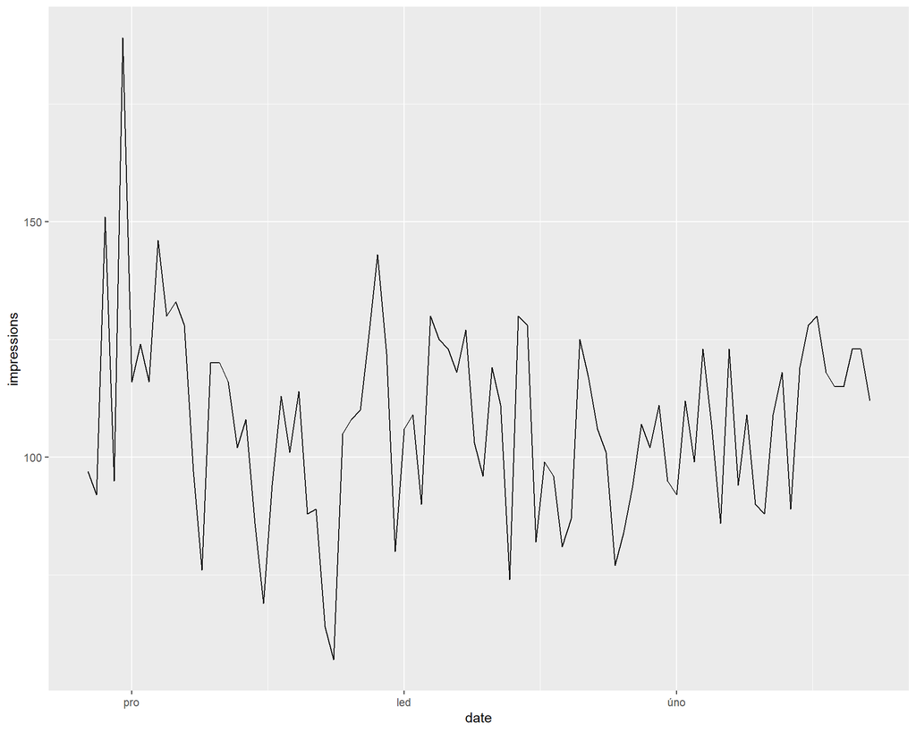

```r
search_analytics(
  siteURL = my_site,
  startDate = today() - 92,
  endDate = today() - 3,
  dimensions = "date"
) |>
  ggplot(aes(x = date, y = impressions)) +
  geom_line()
```

## Časová řada - fasetová, po dnech

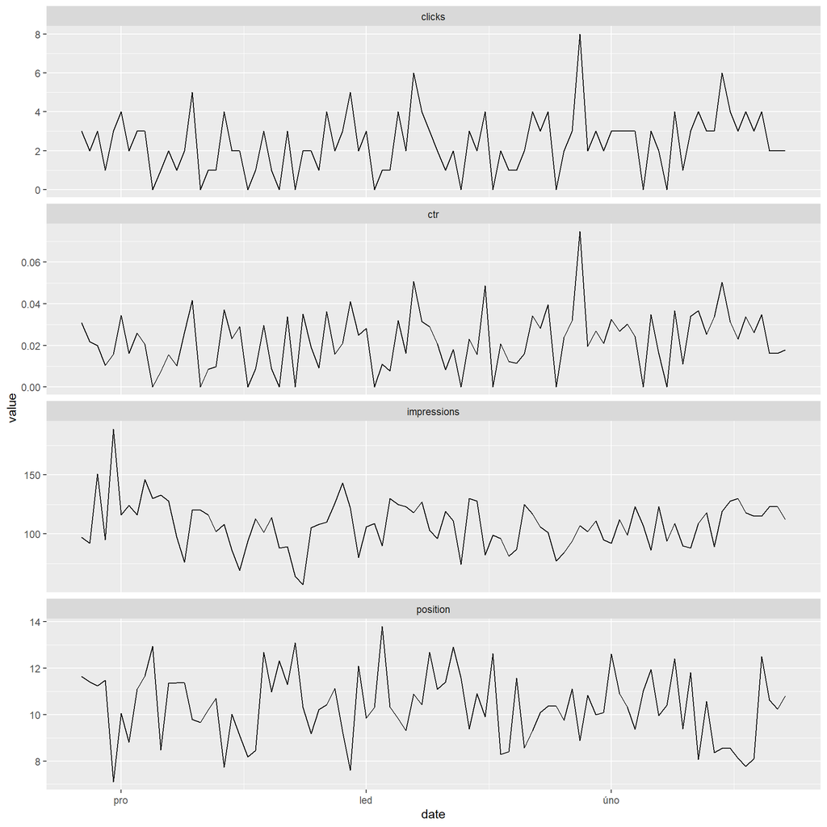

```r
search_analytics(
  siteURL = my_site,
  startDate = today() - 92,
  endDate = today() - 3,
  dimensions = "date"
) |>
  pivot_longer(
    cols = !date, names_to = "metric"
  ) |>
  ggplot(aes(x = date, y = value)) +
  geom_line() +
  facet_wrap(
    ~metric, scales = "free_y", ncol = 1
  )
```

## Funkce `pivot_longer`

Převádí širokou tabulku na dlouhou. Pro fasetový graf se používá velmi často.

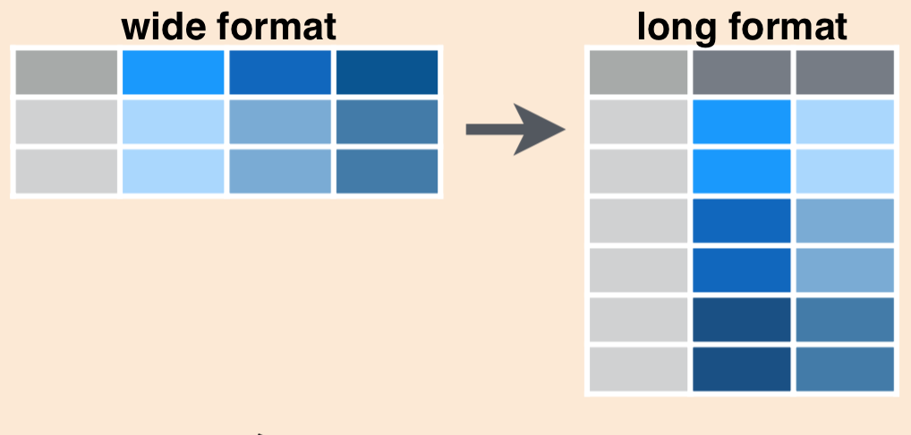

# Náměty na další využití R

## SEO analýzy pro klienty

- Reportování výsledků ve složitější struktuře, než umožňuje Data Studio (segmentace podle dotazů, stránek, zemí apod.).
- Vyhledávání příležitostí ke zlepšení – dotazy, které jsou v klíčovce (nebo v Google Ads) a nejsou v Search Consoli, porovnání výsledků ve více zemích/jazycích atd.
- Příprava na plošnou změnu URL a kontrola po změně – párování stránek podle podobnosti titulku a/nebo URL.
- Vyhodnocování SEO A/B testů.
- Úvodní audity webu – Screaming Frog + Search Console + Analytics.
- Využívání OpenAI API.

## Využití v jiných oblastech

- Vyhodnocování efektivity reklamy.
- Zpracování uživatelských výzkumů a výzkumů trhu.
- Zákaznická analytika, RFM modely, churn analysis u SAAS subscription modelů atd.
- Analýza konvezního poměru a vracejících se zákazníků – hledání vzorců, které ovllivňují klíčové metriky.
- Scrapování informací z webu.
- Rozpočtování, finanční analýzy, cokoli, co se dá udělat v Excelu.

**Tip**

Vyrobil jsem [balíček, který z libovolného českého jména pozná pohlaví](https://github.com/MarekProkop/names.cze).